# Not just vicariance: phylogeography of a Sonoran Desert euphorb indicates a major role of range expansion along the Baja peninsula

MOLECULAR ECOLOGY. 2009.

baja california

euphorbia

landscape history

population structure

statistical phylogeography

Authors

Affiliation

Ryan C. Garrick

John D. Nason

Crystal A. Meadows

[Rodney J. Dyer](https://dyerlab.org)

Center for Environmental Studies

Published

May 1, 2009

Doi

10.1111/j.1365-294X.2009.04148.x

[figure not shown]

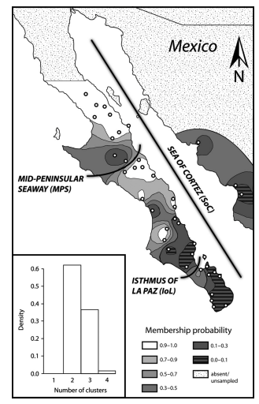

## Abstract

To examine the generality of population-level impacts of ancient vicariance identified for numerous arid-adapted animal taxa along the Baja peninsula, we tested phylogeographical hypotheses in a similarly distributed desert plant, Euphorbia lomelii (Euphorbiaceae). In light of fossil data indicating marked changes in the distributions of Baja floristic assemblages throughout the Holocene and earlier, we also examined evidence for range expansion over more recent temporal scales. Two classes of complementary analytical approaches hypothesis-testing and hypothesis-generating were used to exploit phylogeographical signal from chloroplast DNA sequence data and genotypic data from six codominant nuclear intron markers. Sequence data are consistent with a scenario of mid-peninsular vicariance originating c. 1 million years ago (Ma). Alternative vicariance scenarios representing earlier splitting events inferred for some animals (e.g. Isthmus of La Paz inundation, c. 3 Ma; Sea of Cortez formation, c. 5 Ma) were rejected. Nested clade phylo-geographical analysis corroborated coalescent simulation-based inferences. Nuclear markers broadened the temporal spectrum over which phylogeographical scenarios could be addressed, and provided strong evidence for recent range expansions along the north-south axis of the Baja peninsula. In contrast to previous plant studies in this region, however, the expansions do not appear to have been in a strictly northward direction. These findings contribute to a growing appreciation of the complexity of organismal responses to past climatic and geological changes even when taxa have evolved in the same landscape context.